# Machine Learning

John Hamre III

August 11, 2017

# Overview

In this presentation I show some of the ways computers can “learn” or be trained, and then predict classifications based off of training sets.

# Bullet Points

- To begin with machine learning I start with knn prediction. It is a powerful and straight forward algorithm to use in R
- PCA clustering is demonstrated next, and is more complicated because it uses eigen values to project multi-dimensional data into two dimensions
- Next, we go into tree-based classification methods of machine learning by looking at rpart and random forest algorithms
- After an important gene or factor is found it can be used as a measure of prediction -Finally, I end with clustering as a means of prediction by using k-means and PAM clustering

# k-nearest neighbors algorithm (k-NN) is a non-parametric method used for classification and regression (wikipedia)

```r
library(HiDimDA)
data("AlonDS")
library(class)

set.seed(1234)
ind <- sample(2, nrow(AlonDS), replace=TRUE, prob=c(.39, 0.61))
apo.training <- AlonDS[ind==1 , 2:2001]
apo.test <- AlonDS[ind==2 , 2:2001]
apo.trainlabels <- AlonDS[ind==1, 1]
apo.testlabels <- AlonDS[ind==2, 1]
apo_pred <- knn(apo.training, apo.test, apo.trainlabels, k=1)
table(apo_pred, apo.testlabels)
```

```
##          apo.testlabels
## apo_pred  colonc healthy
##   colonc      25       2
##   healthy      2      11
```

# PCA dimension reduction

```r
alon.data <- (AlonDS[1:dim(AlonDS)[1], 2:dim(AlonDS)[2]])
alon.names <- read.csv("data/alon.names.csv", header=F)
Alon.cl <- c(0,1,0,1,0,1,0,1,0,1,0,1,0,1,0,1,0,1,0,1,0,1,0,1,0,0,0,0,0,0,0,0,0,0,0,0,0,0,1,0,0,1,1,0,0,0,0,1,0,1,1,0,0,1,1,0,0,0,0,1,0,1)
AlonFactor <- factor(Alon.cl,levels=0:1, labels= c("colonc","healthy"))
talon.data <- t(alon.data)
eigen(cor(talon.data))$values[1:5]
```

```
## [1] 46.266564  2.831612  2.264533  1.758461  1.151688
```

```r
data <- talon.data; p <- ncol(data); n <- nrow(data) ; nboot<-1000
eigenvalues <- array(dim=c(nboot,p))
for (i in 1:nboot) {
    dat.star <- data[sample(1:n,replace=TRUE),]
    eigenvalues[i,] <- eigen(cor(dat.star))$values
}
for (j in 1:5) {
    print(quantile(eigenvalues[,j],c(0.025,0.975)))
}
```

```
##     2.5%    97.5%
## 44.36836 48.28612
##     2.5%    97.5%
## 2.450823 3.759073
##     2.5%    97.5%
## 1.785127 2.827118
##     2.5%    97.5%
## 1.382515 2.014506
##     2.5%    97.5%
## 1.011605 1.421319
```

# PCA results

```r
sum(eigen(cor(talon.data))$values[1:5])/62*100
```

```
## [1] 87.53687
```

```r
#Thus, the first five components represent more than 87% of the variance in the data. The data can allow for a reduction in dimensions from
#sixty two data points to five, while still capturing over 87% of the total variance

# to verify that the correlations between the patients are positive
# we run;
-eigen(cor(talon.data))$vec[,1:5]
```

```
##             [,1]         [,2]         [,3]         [,4]         [,5]
##  [1,] 0.13334450  0.033986091  0.064299240  0.190182448  0.087596270
##  [2,] 0.13101243  0.055453409 -0.160080373  0.192870293  0.065330616
##  [3,] 0.08123138  0.381194248  0.254511766 -0.158840079  0.066887819
##  [4,] 0.12186663  0.187345101  0.024326909  0.076170309  0.227739581
##  [5,] 0.13492308 -0.025234418  0.064778140 -0.131490100  0.106656352
##  [6,] 0.12573668 -0.042508361 -0.162798987 -0.243283225  0.205817286
##  [7,] 0.13142976 -0.067702980  0.063955075  0.139911681  0.108777444
##  [8,] 0.11497311 -0.040887571 -0.147787136 -0.086017008  0.171674091
##  [9,] 0.12035762 -0.123376691  0.127601183  0.018987419  0.194064424
## [10,] 0.12759766  0.073671501 -0.135938797 -0.112838720  0.114489142
## [11,] 0.11994081 -0.165215734  0.028956883  0.037587940 -0.130940977
## [12,] 0.13114523  0.087751355 -0.077048073  0.079323831  0.095345885
## [13,] 0.13671340 -0.055573830  0.010252231 -0.021086622  0.114873382
## [14,] 0.11569421  0.038688741 -0.049658214 -0.029725807  0.199764625
```

[output cut: 48 more lines]

# PCA results in five dimensions

```r
#From the previous slide we can match up the negative and positive signs with what we actually observed and express as;
Alon.cl
```

```
##  [1] 0 1 0 1 0 1 0 1 0 1 0 1 0 1 0 1 0 1 0 1 0 1 0 1 0 0 0 0 0 0 0 0 0 0 0
## [36] 0 0 0 1 0 0 1 1 0 0 0 0 1 0 1 1 0 0 1 1 0 0 0 0 1 0 1
```

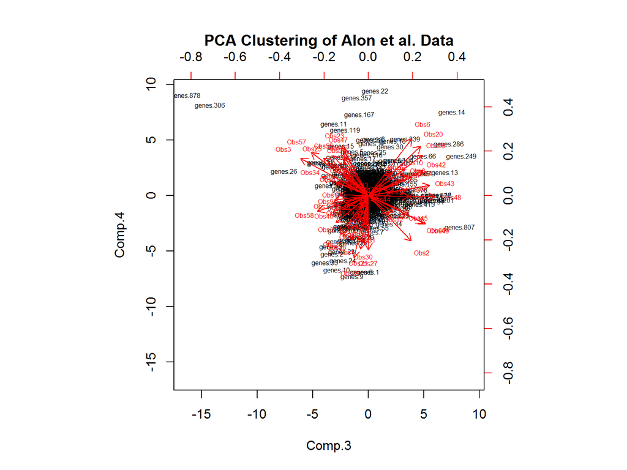

```r
#By matching these we find that the 3rd and 4th dimensions matched the real data best. We can plot these with a biplot to show vectors
biplot(princomp(data,cor=TRUE),choices = c(3,4), pc.biplot=TRUE,cex=0.5,expand=0.8, main = "PCA Clustering of Alon et al. Data")
```

```r
#There is a clear seperation from the left and right in the biplot
```

# PCA results; finding the top genes

```r
#No we can prints the first ten gene names with respect to the third principal comonent to find out what the main genes of differentiating diseased and healthy state
pca <- princomp(talon.data, center = TRUE, cor=TRUE, scores=TRUE)
o <- order(pca$scores[,3])
alon.names[o[1:10],6]
```

```
##  [1] IG GAMMA-1 CHAIN C REGION (HUMAN);.
##  [2] Human Ig gamma3 heavy chain disease OMM protein mRNA.
##  [3] 40S RIBOSOMAL PROTEIN S18 (Homo sapiens)
##  [4] LAMININ RECEPTOR (HUMAN);.
##  [5] 60S RIBOSOMAL PROTEIN L30E (Kluyveromyces lactis)
##  [6] 40S RIBOSOMAL PROTEIN S24 (HUMAN).
##  [7] P24050 40S RIBOSOMAL PROTEIN.
##  [8] EUKARYOTIC INITIATION FACTOR 4A (Oryctolagus cuniculus)
##  [9] EUKARYOTIC INITIATION FACTOR 4A (Oryctolagus cuniculus)
## [10] 40S RIBOSOMAL PROTEIN S6 (Nicotiana tabacum)
## 1824 Levels:  ...
```

```r
pr.out =prcomp (alon.data , scale =TRUE)
```

# rpart finds important genes with recursive partioning and regression to make predictions

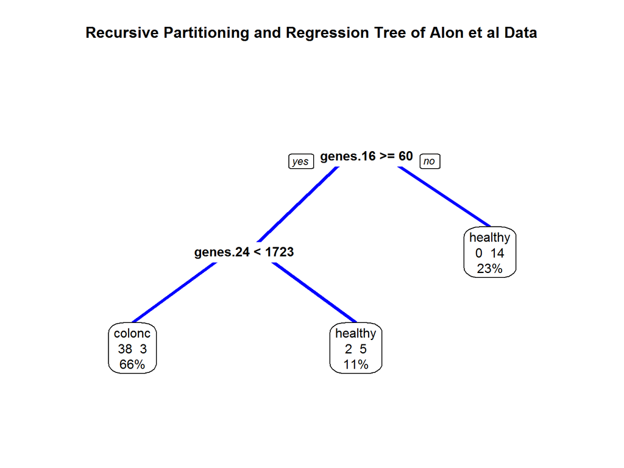

```r
library(rpart.plot)

row.names(talon.data)<- paste("gene", 1:2000, sep = "")

alonRpart <- rpart(AlonFactor~., data=alon.data, method="class", cp=0.001)
prp(alonRpart,  branch.lwd=4,  branch.col="blue",  extra=101, main="Recursive Partitioning and Regression Tree of Alon et al Data")
```

```r
alon.names[ 16, 6]
```

```
## [1] Human tra1 mRNA for human homologue of murine tumor rejection antigen gp961
## 1824 Levels:  ...
```

```r
alon.names[ 24, 6]
```

```
## [1] THYMOSIN BETA-4 (HUMAN);.
## 1824 Levels:  ...
```

# Random forests or random decision forests operate by constructing a multitude of decision trees at training time and outputting mean prediction (regression) of the individual trees. (wikipedia)

```r
library(randomForest)
set.seed(1234)
alon.rf <- randomForest(grouping ~ ., data=AlonDS, importance=TRUE,
                      proximity=TRUE)

#We can predict the diseased state
 print(alon.rf)
```

```
##
## Call:
##  randomForest(formula = grouping ~ ., data = AlonDS, importance = TRUE,      proximity = TRUE)
##                Type of random forest: classification
##                      Number of trees: 500
## No. of variables tried at each split: 44
##
##         OOB estimate of  error rate: 19.35%
## Confusion matrix:
##         colonc healthy class.error
## colonc      34       6   0.1500000
## healthy      6      16   0.2727273
```